# R Notebook

```r
# TranslationAeneid228     <- gutenberg_download(228)
# TranslationAeneid18466   <- gutenberg_download(18466)
# TranslationAeneid22456   <- gutenberg_download(22456)
# TranslationAeneid29358   <- gutenberg_download(29358)
# TranslationAeneid49844   <- gutenberg_download(49844)

wf = TranslationAeneid228 %>% unnest_tokens(word,text) %>%  filter( word %in% concordance_words)%>% select(word)  %>% count(word)

wf <- wf %>% pivot_wider(names_from = word, values_from = n) %>% mutate(WorkTitle = 'TranslationAeneid228') %>% select(WorkTitle,everything())

wfAnalysis <- add_row(wfAnalysis,wf)


wf = TranslationAeneid18466 %>% unnest_tokens(word,text) %>%  filter( word %in% concordance_words)%>% select(word)  %>% count(word)

wf <- wf %>% pivot_wider(names_from = word, values_from = n) %>% mutate(WorkTitle = 'TranslationAeneid18466') %>% select(WorkTitle,everything())

wfAnalysis <- add_row(wfAnalysis,wf)


wf = TranslationAeneid22456 %>% unnest_tokens(word,text) %>%  filter( word %in% concordance_words)%>% select(word)  %>% count(word)

wf <- wf %>% pivot_wider(names_from = word, values_from = n) %>% mutate(WorkTitle = 'TranslationAeneid22456') %>% select(WorkTitle,everything())

wfAnalysis <- add_row(wfAnalysis,wf)

wf = TranslationAeneid29358 %>% unnest_tokens(word,text) %>%  filter( word %in% concordance_words)%>% select(word)  %>% count(word)

wf <- wf %>% pivot_wider(names_from = word, values_from = n) %>% mutate(WorkTitle = 'TranslationAeneid29358') %>% select(WorkTitle,everything())

wfAnalysis <- add_row(wfAnalysis,wf)

wf = TranslationAeneid49844 %>% unnest_tokens(word,text) %>%  filter( word %in% concordance_words)%>% select(word)  %>% count(word)

wf <- wf %>% pivot_wider(names_from = word, values_from = n) %>% mutate(WorkTitle = 'TranslationAeneid49844') %>% select(WorkTitle,everything())

wfAnalysis <- add_row(wfAnalysis,wf)


wfAnalysis
```

| WorkTitle | bad | black | blue | good | green | kind | left | many | none | old | one | only | orange | purple | red | right | strong | swift | white | yellow |
| --- | --- | --- | --- | --- | --- | --- | --- | --- | --- | --- | --- | --- | --- | --- | --- | --- | --- | --- | --- | --- |
| TheLatinAeneid | 47 | 70 | 12 | 43 | 15 | 30 | 14 | 182 | 57 | 30 | 124 | 145 | 7 | 15 | 4 | 123 | 78 | 25 | 37 | 26 |
| TranslationAeneid228 | 4 | 29 | 5 | 35 | 24 | 23 | 84 | 26 | 13 | 89 | 119 | 50 | NA | 52 | 6 | 43 | 39 | 28 | 27 | 21 |
| TranslationAeneid18466 | NA | 37 | 13 | 50 | 19 | 24 | 78 | 109 | 43 | 104 | 166 | 39 | NA | 28 | 17 | 43 | 20 | 39 | 31 | 7 |
| TranslationAeneid22456 | 1 | 38 | 10 | 40 | 21 | 1 | 113 | 125 | 38 | 97 | 179 | 27 | NA | 17 | 7 | 61 | 23 | 22 | 39 | 12 |
| TranslationAeneid29358 | NA | 59 | 18 | 76 | 19 | 29 | 112 | 171 | 42 | 85 | 201 | 23 | NA | 30 | 13 | 63 | 23 | 64 | 38 | 22 |
| TranslationAeneid49844 | 13 | 4 | 7 | 74 | 3 | 19 | 39 | 70 | 8 | 39 | 265 | 107 | NA | NA | 8 | 21 | 14 | 6 | 1 | 6 |

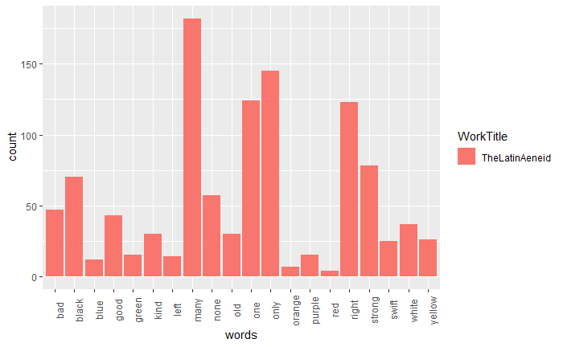

```r
ggplot(longwfAnalysis %>% filter(WorkTitle=="TheLatinAeneid" ), aes(words,count,fill=WorkTitle)) + geom_col()+theme(axis.text.x = element_text(angle = 90))
```

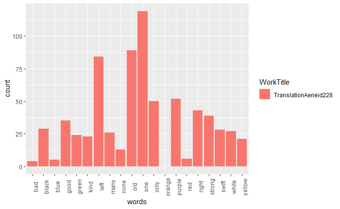

```r
ggplot(longwfAnalysis %>% filter(WorkTitle=="TranslationAeneid228" ), aes(words,count,fill=WorkTitle)) + geom_col()+theme(axis.text.x = element_text(angle = 90))
```

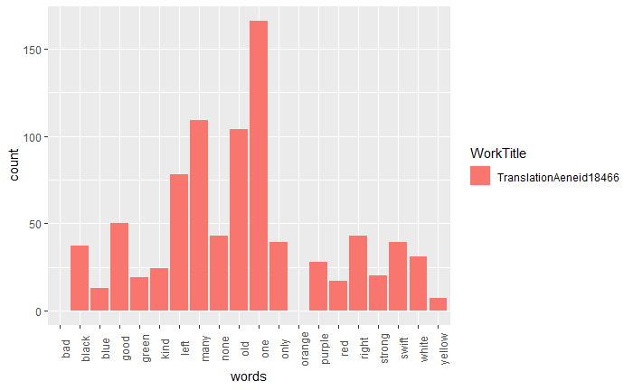

```r
ggplot(longwfAnalysis %>% filter(WorkTitle=="TranslationAeneid18466" ), aes(words,count,fill=WorkTitle)) + geom_col()+theme(axis.text.x = element_text(angle = 90))
```

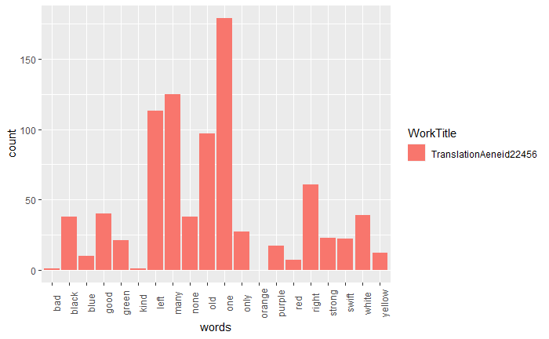

```r
ggplot(longwfAnalysis %>% filter(WorkTitle=="TranslationAeneid22456" ), aes(words,count,fill=WorkTitle)) + geom_col()+theme(axis.text.x = element_text(angle = 90))
```

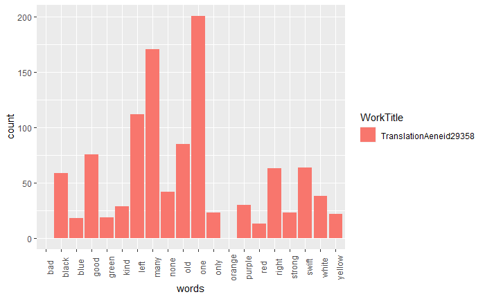

```r
ggplot(longwfAnalysis %>% filter(WorkTitle=="TranslationAeneid29358" ), aes(words,count,fill=WorkTitle)) + geom_col()+theme(axis.text.x = element_text(angle = 90))
```

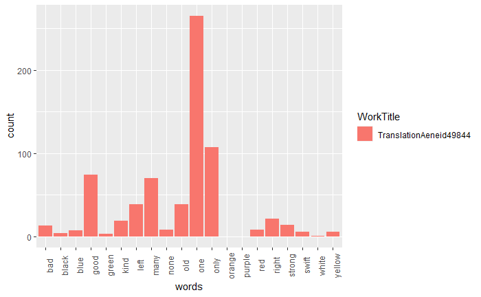

```r
ggplot(longwfAnalysis %>% filter(WorkTitle=="TranslationAeneid49844" ), aes(words,count,fill=WorkTitle)) + geom_col()+theme(axis.text.x = element_text(angle = 90))
```

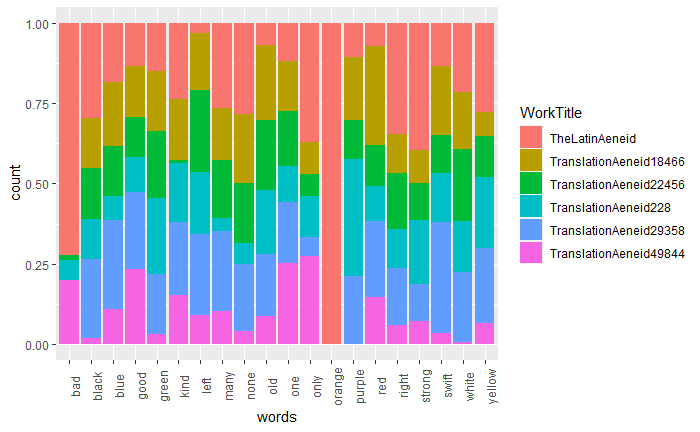

```r
ggplot(longwfAnalysis, aes(words,count,fill=WorkTitle)) + geom_col(position = 'fill')+theme(axis.text.x = element_text(angle = 90))
```

## Further Research

A number of things could enhance this investigation, expanding to multiple ediotions of the same book in the same language should show us a ‘control’ in natural divergence as more material is added or revised in each edition.

Additional context clues using NLP could enhance or eliminate a need for a concordance. A broader concordance might capture a more solid signature. Development of a metric to quantify ‘distance’ from the original or first edition could be ddeveloped based on the wf-signature of the original document.